# final_project

[figure not shown]

By: Michael Del Bene

## Introduction

In the NFL, and football in general, the Quarterback is said to be the most important player on the field. This is because he has the ball in his hands on every offensive play, and also makes a lot of the play calls. He is usually the leader of his team, on and off the field. With that, I am interested in how a Quarterbacks statistics affect their win rate so I am going to attempt to predict QB win ratios based off of their statistics using data analysis techniques.

## Data Scraping

To begin my data science project I will need to first import all of the libraries I am going to be using. Which is what this next cell accomplishes. After this I will begin to scrape the data, which is where I gather data from a website that has the information I need to do a data analysis. I will be using www.pro-football-reference.com, a website that has all the data I wanted about Quarterbacks from the 2019 and 2020 season so far.

```python
import pandas as pd
import numpy as np
import matplotlib.pyplot as plt
from bs4 import BeautifulSoup
import requests
import statsmodels.formula.api as smf
from sklearn.linear_model import LinearRegression
import statsmodels.api as sm
from statsmodels.formula.api import ols
import seaborn as sns
!pip3 install lxml
```

```python
url = "https://www.pro-football-reference.com/years/2019/passing.htm"
reqs = []

for i in range(2019, 2021):
    reqs.append(requests.get(url))
    # change 2010 to 2011 in the url, 2011 to 2012, etc.
    url = url.replace(str(i), str(i+1))
tables = []
for r in reqs:
    root = BeautifulSoup(r.content, "html.parser")
    tables.append(root.find("table"))
# converts the table to a dataframe. this is currently only the 2010 season, because
# tables[0], the first page we scraped, is 2010
temp = pd.read_html(str(tables[0]))[0]
data_2020 = pd.read_html(str(tables[1]))[0]
temp
```

|  | Rk | Player | Tm | Age | Pos | G | GS | QBrec | Cmp | Att | ... | Y/G | Rate | QBR | Sk | Yds.1 | NY/A | ANY/A | Sk% | 4QC | GWD |
| --- | --- | --- | --- | --- | --- | --- | --- | --- | --- | --- | --- | --- | --- | --- | --- | --- | --- | --- | --- | --- | --- |
| 0 | 1 | Jared Goff | LAR | 25 | QB | 16 | 16 | 9-7-0 | 394 | 626 | ... | 289.9 | 86.5 | 50.2 | 22 | 170 | 6.90 | 6.46 | 3.4 | 1 | 2 |
| 1 | 2 | Jameis Winston | TAM | 25 | QB | 16 | 16 | 7-9-0 | 380 | 626 | ... | 319.3 | 84.3 | 59.1 | 47 | 282 | 7.17 | 6.15 | 7.0 | 2 | 2 |
| 2 | 3 | Matt Ryan | ATL | 34 | QB | 15 | 15 | 7-8-0 | 408 | 616 | ... | 297.7 | 92.1 | 60.4 | 48 | 316 | 6.25 | 6.08 | 7.2 | 3 | 2 |
| 3 | 4 | Tom Brady | NWE | 42 | QB | 16 | 16 | 12-4-0 | 373 | 613 | ... | 253.6 | 88.0 | 54.5 | 27 | 185 | 6.05 | 6.24 | 4.2 | 1 | 1 |
| 4 | 5 | Carson Wentz | PHI | 27 | QB | 16 | 16 | 9-7-0 | 388 | 607 | ... | 252.4 | 93.1 | 64.8 | 37 | 230 | 5.91 | 6.26 | 5.7 | 2 | 4 |
| ... | ... | ... | ... | ... | ... | ... | ... | ... | ... | ... | ... | ... | ... | ... | ... | ... | ... | ... | ... | ... | ... |
| 100 | 98 | Emmanuel Sanders | 2TM | 32 | NaN | 17 | 16 | NaN | 1 | 1 | ... | 2.1 | 158.3 | NaN | 0 | 0 | 35.00 | 55.00 | 0.0 | NaN | NaN |
| 101 | 99 | Steven Sims | WAS | 22 | NaN | 16 | 2 | NaN | 0 | 1 | ... | 0.0 | 39.6 | NaN | 0 | 0 | 0.00 | 0.00 | 0.0 | NaN | NaN |
| 102 | 100 | Courtland Sutton * | DEN | 24 | WR | 16 | 14 | NaN | 1 | 1 | ... | 2.4 | 118.7 | 100.0 | 0 | 0 | 38.00 | 38.00 | 0.0 | NaN | NaN |
| 103 | 101 | Alex Tanney | NYG | 32 | NaN | 1 | 0 | NaN | 1 | 1 | ... | 1.0 | 79.2 | 1.6 | 0 | 0 | 1.00 | 1.00 | 0.0 | NaN | NaN |
| 104 | 102 | James White | NWE | 27 | NaN | 15 | 1 | NaN | 1 | 1 | ... | 2.3 | 118.7 | 99.9 | 0 | 0 | 35.00 | 35.00 | 0.0 | NaN | NaN |

105 rows × 31 columns

My variable temp is storing the 2019 passer data and the variable data_2020 is storing the 2020 passer dataframe. I also want to look at QB rushing statistics so I will be scraping from a different table from the same website to accomplish this.

```python
url = "https://www.pro-football-reference.com/years/2019/rushing.htm"
reqs = []

for i in range(2019, 2021):
    reqs.append(requests.get(url))
    # change 2010 to 2011 in the url, 2011 to 2012, etc.
    url = url.replace(str(i), str(i+1))
tables = []
for r in reqs:
    root = BeautifulSoup(r.content, "html.parser")
    tables.append(root.find("table"))
# converts the table to a dataframe. this is currently only the 2010 season, because
# tables[0], the first page we scraped, is 2010
rushing = pd.read_html(str(tables[0]))[0]
rushing_2020 = pd.read_html(str(tables[1]))[0]
rushing
```

|  | Unnamed: 0_level_0 Rk | Unnamed: 1_level_0 Player | Unnamed: 2_level_0 Tm | Unnamed: 3_level_0 Age | Unnamed: 4_level_0 Pos | Games G | Games GS | Rushing Att | Rushing Yds | Rushing TD | Rushing 1D | Rushing Lng | Rushing Y/A | Rushing Y/G | Unnamed: 14_level_0 Fmb |
| --- | --- | --- | --- | --- | --- | --- | --- | --- | --- | --- | --- | --- | --- | --- | --- |
| 0 | 1 | Derrick Henry * | TEN | 25 | RB | 15 | 15 | 303 | 1540 | 16 | 73 | 74 | 5.1 | 102.7 | 5 |
| 1 | 2 | Ezekiel Elliott* | DAL | 24 | RB | 16 | 16 | 301 | 1357 | 12 | 78 | 33 | 4.5 | 84.8 | 3 |
| 2 | 3 | Nick Chubb* | CLE | 24 | RB | 16 | 16 | 298 | 1494 | 8 | 62 | 88 | 5.0 | 93.4 | 3 |
| 3 | 4 | Christian McCaffrey*+ | CAR | 23 | RB | 16 | 16 | 287 | 1387 | 15 | 57 | 84 | 4.8 | 86.7 | 1 |
| 4 | 5 | Chris Carson | SEA | 25 | RB | 15 | 15 | 278 | 1230 | 7 | 75 | 59 | 4.4 | 82.0 | 7 |
| ... | ... | ... | ... | ... | ... | ... | ... | ... | ... | ... | ... | ... | ... | ... | ... |
| 340 | 330 | Danny Vitale | GNB | 26 | NaN | 15 | 4 | 1 | 3 | 0 | 0 | 3 | 3.0 | 0.2 | 0 |
| 341 | 331 | Greg Ward | PHI | 24 | NaN | 7 | 3 | 1 | 5 | 0 | 0 | 5 | 5.0 | 0.7 | 0 |
| 342 | 332 | Trevon Wesco | NYJ | 24 | NaN | 16 | 1 | 1 | 2 | 0 | 1 | 2 | 2.0 | 0.1 | 0 |
| 343 | 333 | Mike Williams | LAC | 25 | WR | 15 | 15 | 1 | 2 | 0 | 0 | 2 | 2.0 | 0.1 | 0 |
| 344 | 334 | Jarius Wright | CAR | 30 | WR/wr | 16 | 9 | 1 | -7 | 0 | 0 | -7 | -7.0 | -0.4 | 0 |

345 rows × 15 columns

The variable rushing now stores the rushing data for 2019 and rushing_2020 for the 2020 season.

## Data Tidying

```python
# column titles. this removes them
temp = temp[~temp["GS"].str.contains("GS")]

# preparing QBrec for further analysis

temp["QBrec"] = temp["QBrec"].astype(str)
temp = temp[~temp["QBrec"].str.contains("NaN")]
temp = temp[~temp["QBrec"].str.contains("nan")]

temp["GS"] = pd.to_numeric(temp["GS"])


data_2020 = data_2020[~data_2020["GS"].str.contains("GS")]
data_2020["QBrec"] = data_2020["QBrec"].astype(str)
data_2020 = data_2020[~data_2020["QBrec"].str.contains("NaN")]
data_2020 = data_2020[~data_2020["QBrec"].str.contains("nan")]

data_2020["GS"] = pd.to_numeric(data_2020["GS"])
```

```python
rushing.columns = ['Rk', 'Player', 'Tm', 'Age','Pos','G','GS','RAtt','RYds', 'RTD', '1D', 'Lng', 'RY/A', 'RY/G', 'Fmb']


# remove column titles from middle of dataframe
rushing = rushing[~rushing["GS"].str.contains("GS")]

rushing["GS"] = pd.to_numeric(rushing["GS"])

rushing = rushing.loc[rushing['Pos'] == 'QB']
rushing = rushing.drop(["1D", "Lng", "Tm", "Age", "Pos", "G", "GS", "Rk"], axis = 1)


rushing_2020.columns = ['Rk', 'Player', 'Tm', 'Age','Pos','G','GS','RAtt','RYds', 'RTD', '1D', 'Lng', 'RY/A', 'RY/G', 'Fmb']


# remove column titles from middle of dataframe
rushing_2020 = rushing_2020[~rushing_2020["GS"].str.contains("GS")]

rushing_2020["GS"] = pd.to_numeric(rushing_2020["GS"])

rushing_2020 = rushing_2020.loc[rushing_2020['Pos'] == 'QB']
rushing_2020 = rushing_2020.drop(["1D", "Lng", "Tm", "Age", "Pos", "G", "GS", "Rk"], axis = 1)
rushing_2020.head()
```

|  | Player | RAtt | RYds | RTD | RY/A | RY/G | Fmb |
| --- | --- | --- | --- | --- | --- | --- | --- |
| 24 | Lamar Jackson | 135 | 828 | 7 | 6.1 | 63.7 | 9 |
| 30 | Kyler Murray | 123 | 741 | 11 | 6.0 | 52.9 | 9 |
| 31 | Cam Newton | 122 | 489 | 11 | 4.0 | 37.6 | 6 |
| 44 | Josh Allen | 96 | 383 | 8 | 4.0 | 27.4 | 9 |
| 56 | Deshaun Watson | 82 | 394 | 3 | 4.8 | 28.1 | 6 |

Here, we have a list of all of the statistics represented by column heads in our dataframes.

Rk -- Rank This is a count of the rows from top to bottom. It is recalculated following the sorting of a column.

Age -- Player's age on December 31st of that year

Pos -- Position

G -- Games played

GS -- Games started as an offensive or defensive player

QBrec -- Team record in games started by this QB (regular season)

Cmp -- Passes completed

Att -- Passes attempted

Cmp% -- Percentage of Passes Completed

Yds -- Yards Gained by Passing (For teams, sack yardage is deducted from this total)

TD -- Passing Touchdowns

TD% -- Percentage of Touchdowns Thrown when Attempting to Pass

Int -- Interceptions thrown

Int% -- Percentage of Times Intercepted when Attempting to Pass

1D -- First downs passing

Lng -- Longest Completed Pass Thrown (complete since 1975)

Y/A -- Yards gained per pass attempt

AY/A -- Adjusted Yards gained per pass attempt (Passing Yards + 20 *Passing TD - 45* Interceptions) / (Passes Attempted)

Y/C -- Yards gained per pass completion (Passing Yards) / (Passes Completed)

Y/G -- Yards gained per game played

Rate -- Quarterback Rating

QBR -- QBR (ESPN s Total Quarterback Rating, calculated since 2006)

Sk -- Times Sacked (first recorded in 1969, player per game since 1981)

Yds -- Yards lost due to sacks (first recorded in 1969, player per game since 1981)

NY/A -- Net Yards gained per pass attempt (Passing Yards - Sack Yards) / (Passes Attempted + Times Sacked)

ANY/A -- Adjusted Net Yards per Pass Attempt

(Passing Yards - Sack Yards + (20 *Passing TD) - (45* Interceptions)) / (Passes Attempted + Times Sacked)

Sk% -- Percentage of Time Sacked when Attempting to Pass: Times Sacked / (Passes Attempted + Times Sacked)

4QC -- Comebacks led by quarterback. Must be an offensive scoring drive in the 4th quarter, with the team trailing by one score, though not necessarily a drive to take the lead. Only games ending in a win or tie are included.

GWD -- Game-winning drives led by quarterback. Must be an offensive scoring drive in the 4th quarter or overtime that puts the winning team ahead for the last time.

```python
# Only looking at quarterbacks who started atleast half of the seasons games

data = temp[temp["GS"] >= 8]

# Drop unnecessary columns
data = data.drop(["Cmp", "Att", "TD%", "1D", "Lng", "NY/A", "ANY/A", "4QC", "GWD"], axis=1)

data_2020 = data_2020[data_2020["GS"] >= 6]

data_2020 = data_2020.drop(["Cmp", "Att", "TD%", "1D", "Lng", "ANY/A", "4QC", "GWD"], axis=1)

data.head()
```

|  | Rk | Player | Tm | Age | Pos | G | GS | QBrec | Cmp% | Yds | ... | Int% | Y/A | AY/A | Y/C | Y/G | Rate | QBR | Sk | Yds.1 | Sk% |
| --- | --- | --- | --- | --- | --- | --- | --- | --- | --- | --- | --- | --- | --- | --- | --- | --- | --- | --- | --- | --- | --- |
| 0 | 1 | Jared Goff | LAR | 25 | QB | 16 | 16 | 9-7-0 | 62.9 | 4638 | ... | 2.6 | 7.4 | 7.0 | 11.8 | 289.9 | 86.5 | 50.2 | 22 | 170 | 3.4 |
| 1 | 2 | Jameis Winston | TAM | 25 | QB | 16 | 16 | 7-9-0 | 60.7 | 5109 | ... | 4.8 | 8.2 | 7.1 | 13.4 | 319.3 | 84.3 | 59.1 | 47 | 282 | 7.0 |
| 2 | 3 | Matt Ryan | ATL | 34 | QB | 15 | 15 | 7-8-0 | 66.2 | 4466 | ... | 2.3 | 7.3 | 7.1 | 10.9 | 297.7 | 92.1 | 60.4 | 48 | 316 | 7.2 |
| 3 | 4 | Tom Brady | NWE | 42 | QB | 16 | 16 | 12-4-0 | 60.8 | 4057 | ... | 1.3 | 6.6 | 6.8 | 10.9 | 253.6 | 88.0 | 54.5 | 27 | 185 | 4.2 |
| 4 | 5 | Carson Wentz | PHI | 27 | QB | 16 | 16 | 9-7-0 | 63.9 | 4039 | ... | 1.2 | 6.7 | 7.0 | 10.4 | 252.4 | 93.1 | 64.8 | 37 | 230 | 5.7 |

5 rows × 22 columns

```python
# Parse the record column so we can form win percentage
data = (data
         .assign(Wins= data.QBrec.str.split('-').str.get(0),
                 Losses = data.QBrec.str.split('-').str.get(-2),
                 Ties = data.QBrec.str.split('-').str.get(-1)
            )
          )

# Creation of win percentage column based on record
data["Win Percentage"] = 100 * (data["Wins"].astype(int) + data["Ties"].astype(int)*0.5) / data["GS"].astype(int)


data = data.drop(["QBrec", "Wins", "Losses", "Ties"], axis=1)

# Merge passing and rushing data
final = pd.merge(data, rushing, how = "inner", left_on = "Player", right_on = "Player")

final = final.fillna(0)
final.index = range(0,30)
final.head()
```

|  | Rk | Player | Tm | Age | Pos | G | GS | Cmp% | Yds | TD | ... | Sk | Yds.1 | Sk% | Win Percentage | RAtt | RYds | RTD | RY/A | RY/G | Fmb |
| --- | --- | --- | --- | --- | --- | --- | --- | --- | --- | --- | --- | --- | --- | --- | --- | --- | --- | --- | --- | --- | --- |
| 0 | 1 | Jared Goff | LAR | 25 | QB | 16 | 16 | 62.9 | 4638 | 22 | ... | 22 | 170 | 3.4 | 56.250000 | 33 | 40 | 2 | 1.2 | 2.5 | 10 |
| 1 | 2 | Jameis Winston | TAM | 25 | QB | 16 | 16 | 60.7 | 5109 | 33 | ... | 47 | 282 | 7.0 | 43.750000 | 59 | 250 | 1 | 4.2 | 15.6 | 12 |
| 2 | 3 | Matt Ryan | ATL | 34 | QB | 15 | 15 | 66.2 | 4466 | 26 | ... | 48 | 316 | 7.2 | 46.666667 | 34 | 147 | 1 | 4.3 | 9.8 | 9 |
| 3 | 4 | Tom Brady | NWE | 42 | QB | 16 | 16 | 60.8 | 4057 | 24 | ... | 27 | 185 | 4.2 | 75.000000 | 26 | 34 | 3 | 1.3 | 2.1 | 4 |
| 4 | 5 | Carson Wentz | PHI | 27 | QB | 16 | 16 | 63.9 | 4039 | 27 | ... | 37 | 230 | 5.7 | 56.250000 | 62 | 243 | 1 | 3.9 | 15.2 | 16 |

5 rows × 28 columns

```python
# Repeat process for 2020 dataframe

data_2020 = (data_2020
         .assign(Wins= data_2020.QBrec.str.split('-').str.get(0),
                 Losses = data_2020.QBrec.str.split('-').str.get(-2),
                 Ties = data_2020.QBrec.str.split('-').str.get(-1)
            )
          )

data_2020["Win Percentage"] = 100 * (data_2020["Wins"].astype(int) + data_2020["Ties"].astype(int)*0.5) / data_2020["GS"].astype(int)


data_2020 = data_2020.drop(["QBrec", "Wins", "Losses", "Ties"], axis=1)

final_2020 = pd.merge(data_2020, rushing_2020, how = "inner", left_on = "Player", right_on = "Player")

final_2020 = final_2020.fillna(0)
final_2020.head()
```

|  | Rk | Player | Tm | Age | Pos | G | GS | Cmp% | Yds | TD | ... | Yds.1 | NY/A | Sk% | Win Percentage | RAtt | RYds | RTD | RY/A | RY/G | Fmb |
| --- | --- | --- | --- | --- | --- | --- | --- | --- | --- | --- | --- | --- | --- | --- | --- | --- | --- | --- | --- | --- | --- |
| 0 | 1 | Matt Ryan | ATL | 35 | QB | 14 | 14 | 64.2 | 4016 | 22 | ... | 227 | 6.50 | 6.2 | 28.571429 | 25 | 92 | 1 | 3.7 | 6.6 | 3 |
| 1 | 2 | Patrick Mahomes | KAN | 25 | QB | 14 | 14 | 67.3 | 4462 | 36 | ... | 147 | 7.62 | 3.9 | 92.857143 | 59 | 287 | 2 | 4.9 | 20.5 | 5 |
| 2 | 3 | Tom Brady | TAM | 43 | QB | 14 | 14 | 65.1 | 3886 | 32 | ... | 128 | 6.70 | 3.4 | 64.285714 | 25 | 3 | 3 | 0.1 | 0.2 | 4 |
| 3 | 4 | Justin Herbert | LAC | 22 | QB | 13 | 13 | 66.5 | 3781 | 27 | ... | 171 | 6.47 | 4.8 | 30.769231 | 45 | 199 | 4 | 4.4 | 15.3 | 7 |
| 4 | 5 | Ben Roethlisberger | PIT | 38 | QB | 13 | 13 | 66.2 | 3292 | 29 | ... | 97 | 6.01 | 2.1 | 84.615385 | 21 | 13 | 0 | 0.6 | 1.0 | 3 |

5 rows × 29 columns

# Exploratory Data Analysis

In this section I will try to answer the question of "What Quarterback statistics affects their win ratio the most?" This will allow me to then performa exact Linear Regression analysis on these statistics so that I can find weights for them in my formula to predict win ratio. I will do this by plotting data from the database using matplotlib so that I can make visual comparisons and also will use a line of best fit to visualize trends.

The first statistic I will compare with win ratio is passing yards per game because it is generally thought that the more yards a quarterback throws for the better, but is this true?

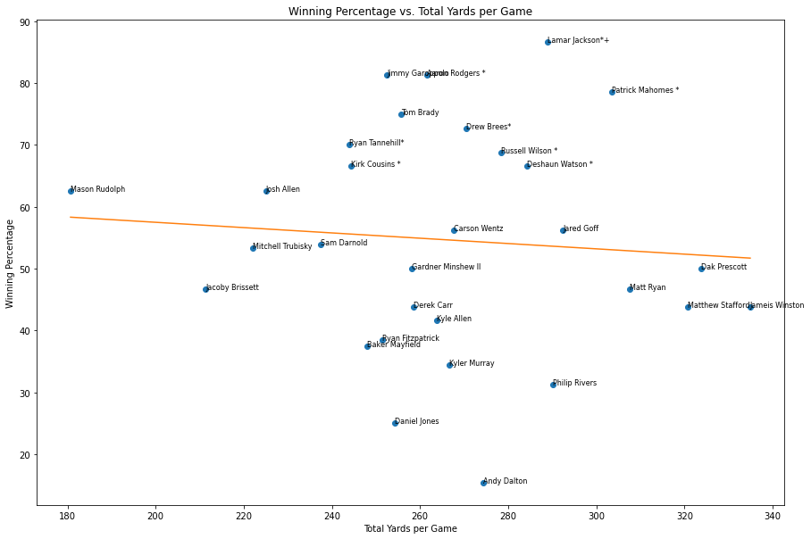

```python
# Yards compared to win rate

x = final['Y/G'].astype(float) + final['RY/G'].astype(float)
y = final['Win Percentage'].astype(float)
z = np.polyfit(x = x, y = y, deg = 1)
f = np.poly1d(z)
x2 = np.linspace(x.min(), x.max(), 100)
y2 = f(x2)
plt.figure(figsize=(15,10))
plt.plot(x, y,'o', x2, y2)


plt.title("Winning Percentage vs. Total Yards per Game")
plt.xlabel("Total Yards per Game")
plt.ylabel("Winning Percentage")

for i, txt in enumerate(final["Player"]):
        plt.annotate(txt, (x[i], y[i]), size = 8)

plt.show()
```

Apparently the more yards a quarterback gains may not be for the better. I can actually see a negative trend on this plot which is extremely interesting. An overwhelming majority of Quarterbacks gain between 220 and 300 yards per game, but the win rates fluctuate so I can conclude that this statistic does not affect win rate. Quarterbacks like Jameis Winston, Dak Prescott, and Matthew Stafford had the most total yards per game, but were only winning about 50% or less of their games. Lets look deeper and see why this might be.

The next statistic I will look at is touchdowns per game.

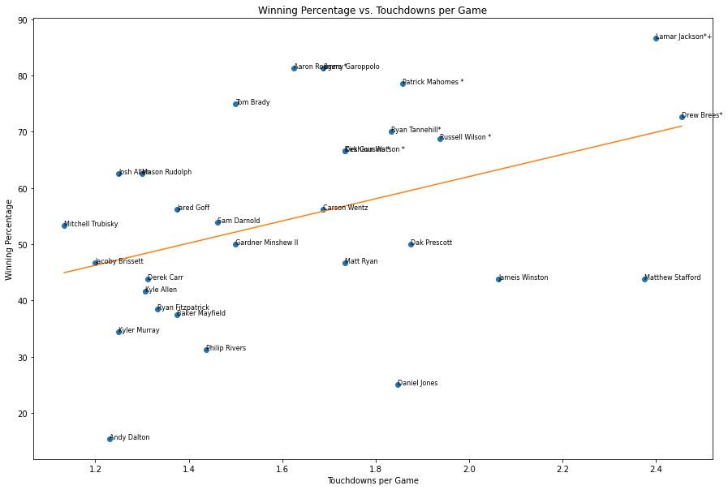

```python
x = final['TD'].astype(float)/final['G'].astype(float)
y = final['Win Percentage'].astype(float)
z = np.polyfit(x = x, y = y, deg = 1)
f = np.poly1d(z)
x2 = np.linspace(x.min(), x.max(), 100)
y2 = f(x2)
plt.figure(figsize=(15,10))
plt.plot(x, y,'o', x2, y2)


plt.title("Winning Percentage vs. Touchdowns per Game")
plt.xlabel("Touchdowns per Game")
plt.ylabel("Winning Percentage")

for i, txt in enumerate(final["Player"]):
        plt.annotate(txt, (x[i], y[i]), size = 8)

plt.show()
```

As expected, I can see a clear trend that the more touchdowns a quarterback throws per game the higher their win percentage will be. This makes a lot of sense because you have to score points to win games, and the quarterbacks who are throwing more touchdowns for their teams are winning more games. However, Jameis Winston, who averaged the most yards per game, also had a high touchdowns per game statistic, but his win ratio was still only around 40%. So clearly touchdowns are not the only thing that contribute to a Quarterback in the NFL's success.

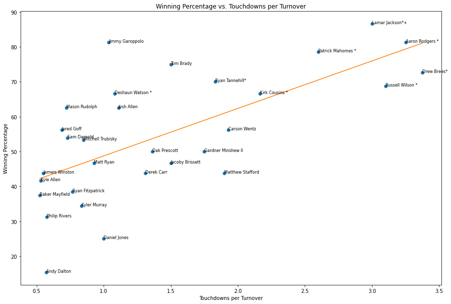

```python
x = final['TD'].astype(float)/(final['Int'].astype(float) + final['Int'].astype(float))
y = final['Win Percentage'].astype(float)
z = np.polyfit(x = x, y = y, deg = 1)
f = np.poly1d(z)
x2 = np.linspace(x.min(), x.max(), 100)
y2 = f(x2)
plt.figure(figsize=(15,10))
plt.plot(x, y,'o', x2, y2)


plt.title("Winning Percentage vs. Touchdowns per Turnover")
plt.xlabel("Touchdowns per Turnover")
plt.ylabel("Winning Percentage")

for i, txt in enumerate(final["Player"]):
        plt.annotate(txt, (x[i], y[i]), size = 8)

plt.show()
```

Let's take a look at another negative statistic for Quarterbacks and see how many times they are sacked per game.

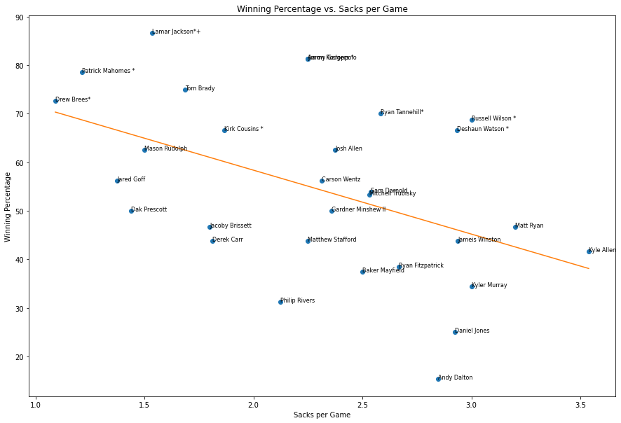

```python
x = final['Sk'].astype(float)/final['G'].astype(float)
y = final['Win Percentage'].astype(float)
z = np.polyfit(x = x, y = y, deg = 1)
f = np.poly1d(z)
x2 = np.linspace(x.min(), x.max(), 100)
y2 = f(x2)
plt.figure(figsize=(15,10))
plt.plot(x, y,'o', x2, y2)


plt.title("Winning Percentage vs. Sacks per Game")
plt.xlabel("Sacks per Game")
plt.ylabel("Winning Percentage")

for i, txt in enumerate(final["Player"]):
        plt.annotate(txt, (x[i], y[i]), size = 8)

plt.show()
```

I can clearly see here that there is a negative trend for Quarterbacks who get sacked the most. The more sacks a quarterback takes results in a lower win percentage. I see similar names like Lamar Jackson, Patrick Mahomes, and Drew Brees at the better end of my data once again, and names like Jameis Winston and Andy Dalton towards the worse half. This is definitely an important statistic and I will use it in our calculation of rating the best winning Quarterbacks.

Let's now look at completion percentages and see how that statistic plays a factor.

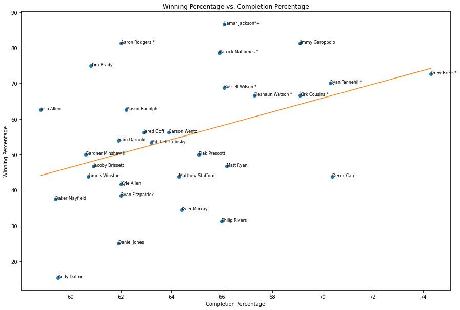

```python
x = final['Cmp%'].astype(float)
y = final['Win Percentage'].astype(float)
z = np.polyfit(x = x, y = y, deg = 1)
f = np.poly1d(z)
x2 = np.linspace(x.min(), x.max(), 100)
y2 = f(x2)
plt.figure(figsize=(15,10))
plt.plot(x, y,'o', x2, y2)


plt.title("Winning Percentage vs. Completion Percentage")
plt.xlabel("Completion Percentage")
plt.ylabel("Winning Percentage")

for i, txt in enumerate(final["Player"]):
        plt.annotate(txt, (x[i], y[i]), size = 8)

plt.show()
```

I see a slight trend here in better completion percentage resulting in a higher win percentage, but it is not overwhelming. Some Quarterbacks with very high win percentages have low completion percentages. This could be the result of them throwing more passes, so I will have to consider that in our calculation.

## Linear Regression Models

I have used plots to visualize winning percentage vs qb stats, but I need to be more precise so that I can put weights on stats in my formula for predicting QB win percentage. So, I will now use a linear regression from stats models api to get an exact coefficient for how each stat affects win percentage. This coefficient will also be able to do some hypothesis testing with the information I find to test if a stat does affect win percentage or not. I can use this coefficient as the weight for the equation I make, and hopefully will be able to create a 1:1 ratio.

```python
X = final['Sk'].astype(float)/final['G'].astype(float)
Y = final["Win Percentage"].astype(float)

X = sm.add_constant(X)

model = sm.OLS(endog=Y,exog=X)

results = model.fit()
results.summary()
```

OLS Regression Results

| Dep. Variable: | Win Percentage | R-squared: | 0.220 |
| --- | --- | --- | --- |
| Model: | OLS | Adj. R-squared: | 0.192 |
| Method: | Least Squares | F-statistic: | 7.903 |
| Date: | Mon, 21 Dec 2020 | Prob (F-statistic): | 0.00891 |
| Time: | 17:34:45 | Log-Likelihood: | -124.79 |
| No. Observations: | 30 | AIC: | 253.6 |
| Df Residuals: | 28 | BIC: | 256.4 |
| Df Model: | 1 |  |  |
| Covariance Type: | nonrobust |  |  |

|  | coef | std err | t | P>\|t\| | [0.025 | 0.975] |
| --- | --- | --- | --- | --- | --- | --- |
| const | 84.7075 | 11.075 | 7.649 | 0.000 | 62.022 | 107.393 |
| 0 | -13.1620 | 4.682 | -2.811 | 0.009 | -22.752 | -3.572 |

| Omnibus: | 1.019 | Durbin-Watson: | 2.053 |
| --- | --- | --- | --- |
| Prob(Omnibus): | 0.601 | Jarque-Bera (JB): | 0.821 |
| Skew: | 0.009 | Prob(JB): | 0.663 |
| Kurtosis: | 2.190 | Cond. No. | 10.4 |

Warnings:  
[1] Standard Errors assume that the covariance matrix of the errors is correctly specified.

I see a clear effect here as win percentage decreased by 13.162 as sacks per game increased by 1. I reject the null hypothesis that sacks per game does not affect win rate.

```python
X = final["Cmp%"].astype(float)
Y = final["Win Percentage"].astype(float)

X = sm.add_constant(X)

model = sm.OLS(endog=Y,exog=X)

results = model.fit()
results.summary()
```

OLS Regression Results

| Dep. Variable: | Win Percentage | R-squared: | 0.166 |
| --- | --- | --- | --- |
| Model: | OLS | Adj. R-squared: | 0.137 |
| Method: | Least Squares | F-statistic: | 5.588 |
| Date: | Mon, 21 Dec 2020 | Prob (F-statistic): | 0.0253 |
| Time: | 17:34:45 | Log-Likelihood: | -125.79 |
| No. Observations: | 30 | AIC: | 255.6 |
| Df Residuals: | 28 | BIC: | 258.4 |
| Df Model: | 1 |  |  |
| Covariance Type: | nonrobust |  |  |

|  | coef | std err | t | P>\|t\| | [0.025 | 0.975] |
| --- | --- | --- | --- | --- | --- | --- |
| const | -70.1253 | 52.882 | -1.326 | 0.196 | -178.450 | 38.199 |
| Cmp% | 1.9427 | 0.822 | 2.364 | 0.025 | 0.259 | 3.626 |

| Omnibus: | 0.250 | Durbin-Watson: | 2.324 |
| --- | --- | --- | --- |
| Prob(Omnibus): | 0.883 | Jarque-Bera (JB): | 0.444 |
| Skew: | 0.050 | Prob(JB): | 0.801 |
| Kurtosis: | 2.412 | Cond. No. | 1.12e+03 |

Warnings:  
[1] Standard Errors assume that the covariance matrix of the errors is correctly specified.  
[2] The condition number is large, 1.12e+03. This might indicate that there are  
strong multicollinearity or other numerical problems.

I can see from the regression summary that win percentage increases by 1.94% as completion percentage increases, so I reject the null hypothesis that completion percentage does not affect win percentage.

```python
X = final["TD"].astype(float)/(final["Int"].astype(float) + final["Fmb"].astype(float))
Y = final["Win Percentage"].astype(float)

X = sm.add_constant(X)

model = sm.OLS(endog=Y,exog=X)

results = model.fit()
results.summary()
```

OLS Regression Results

| Dep. Variable: | Win Percentage | R-squared: | 0.290 |
| --- | --- | --- | --- |
| Model: | OLS | Adj. R-squared: | 0.265 |
| Method: | Least Squares | F-statistic: | 11.44 |
| Date: | Mon, 21 Dec 2020 | Prob (F-statistic): | 0.00214 |
| Time: | 17:34:45 | Log-Likelihood: | -123.38 |
| No. Observations: | 30 | AIC: | 250.8 |
| Df Residuals: | 28 | BIC: | 253.6 |
| Df Model: | 1 |  |  |
| Covariance Type: | nonrobust |  |  |

|  | coef | std err | t | P>\|t\| | [0.025 | 0.975] |
| --- | --- | --- | --- | --- | --- | --- |
| const | 42.1624 | 4.638 | 9.092 | 0.000 | 32.663 | 51.662 |
| 0 | 7.9962 | 2.364 | 3.383 | 0.002 | 3.154 | 12.839 |

| Omnibus: | 0.378 | Durbin-Watson: | 2.032 |
| --- | --- | --- | --- |
| Prob(Omnibus): | 0.828 | Jarque-Bera (JB): | 0.539 |
| Skew: | -0.152 | Prob(JB): | 0.764 |
| Kurtosis: | 2.419 | Cond. No. | 3.84 |

Warnings:  
[1] Standard Errors assume that the covariance matrix of the errors is correctly specified.

Like I saw in my plot this statistic is very important. I see that winning percentage increases by 8% as touchdowns per turnover increases by 1. Again, I am rejecting the null hypothesis.

```python
X = final['Y/G'].astype(float) + final['RY/G'].astype(float)
Y = final["Win Percentage"].astype(float)

X = sm.add_constant(X)

model = sm.OLS(endog=Y,exog=X)

results = model.fit()
results.summary()
```

OLS Regression Results

| Dep. Variable: | Win Percentage | R-squared: | 0.007 |
| --- | --- | --- | --- |
| Model: | OLS | Adj. R-squared: | -0.029 |
| Method: | Least Squares | F-statistic: | 0.1872 |
| Date: | Mon, 21 Dec 2020 | Prob (F-statistic): | 0.669 |
| Time: | 17:34:46 | Log-Likelihood: | -128.42 |
| No. Observations: | 30 | AIC: | 260.8 |
| Df Residuals: | 28 | BIC: | 263.6 |
| Df Model: | 1 |  |  |
| Covariance Type: | nonrobust |  |  |

|  | coef | std err | t | P>\|t\| | [0.025 | 0.975] |
| --- | --- | --- | --- | --- | --- | --- |
| const | 66.0814 | 26.558 | 2.488 | 0.019 | 11.681 | 120.482 |
| 0 | -0.0429 | 0.099 | -0.433 | 0.669 | -0.246 | 0.160 |

| Omnibus: | 0.284 | Durbin-Watson: | 1.972 |
| --- | --- | --- | --- |
| Prob(Omnibus): | 0.868 | Jarque-Bera (JB): | 0.469 |
| Skew: | -0.066 | Prob(JB): | 0.791 |
| Kurtosis: | 2.402 | Cond. No. | 2.15e+03 |

Warnings:  
[1] Standard Errors assume that the covariance matrix of the errors is correctly specified.  
[2] The condition number is large, 2.15e+03. This might indicate that there are  
strong multicollinearity or other numerical problems.

I see a coefficient of basically 0 here as it is less than 0.05 so I will accept the null hypothesis that total yards does not affect win percentage and I will not be using it in my formula.

Now that I have our coefficients for the statistics I analyzed to have affects on win percentage, I want to see how accurate my statistic actually is.

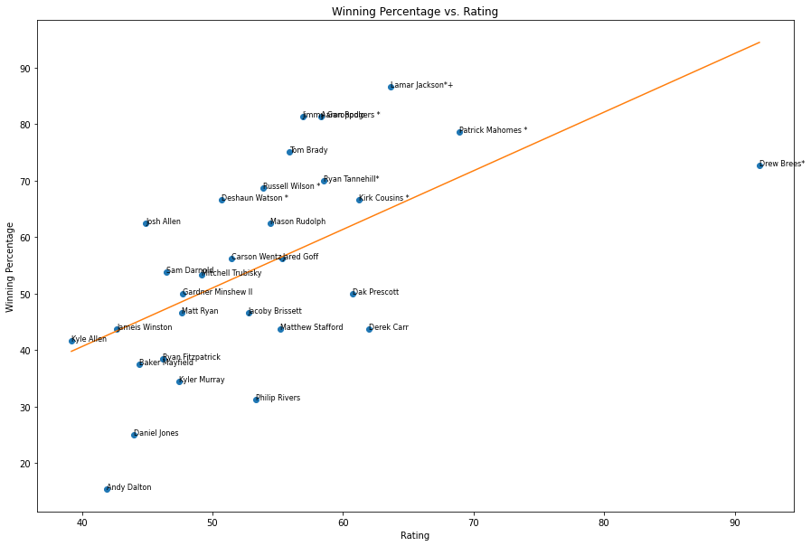

```python
x = (8 * (final["TD"].astype(float)/(final["Int"].astype(float) + final["Fmb"].astype(float))) + \
          1.94 * (final["Cmp%"].astype(float)) - \
          13.162 * final['Sk'].astype(float)/final['G'].astype(float))/2

y = final['Win Percentage'].astype(float)
z = np.polyfit(x = x, y = y, deg = 1)
f = np.poly1d(z)
x2 = np.linspace(x.min(), x.max(), 100)
y2 = f(x2)
plt.figure(figsize=(15,10))
plt.plot(x, y,'o', x2, y2)


plt.title("Winning Percentage vs. Rating")
plt.xlabel("Rating")
plt.ylabel("Winning Percentage")

for i, txt in enumerate(final["Player"]):
        plt.annotate(txt, (x[i], y[i]), size = 8)

plt.show()
```

```python
X = (8 * (final["TD"].astype(float)/(final["Int"].astype(float) + final["Fmb"].astype(float))) + \
          1.94 * (final["Cmp%"].astype(float)) - \
          13.162 * final['Sk'].astype(float)/final['G'].astype(float))/2
Y = final["Win Percentage"].astype(float)

X = sm.add_constant(X)

model = sm.OLS(endog=Y,exog=X)

results = model.fit()
results.summary()
```

OLS Regression Results

| Dep. Variable: | Win Percentage | R-squared: | 0.351 |
| --- | --- | --- | --- |
| Model: | OLS | Adj. R-squared: | 0.328 |
| Method: | Least Squares | F-statistic: | 15.14 |
| Date: | Mon, 21 Dec 2020 | Prob (F-statistic): | 0.000563 |
| Time: | 17:34:46 | Log-Likelihood: | -122.03 |
| No. Observations: | 30 | AIC: | 248.1 |
| Df Residuals: | 28 | BIC: | 250.9 |
| Df Model: | 1 |  |  |
| Covariance Type: | nonrobust |  |  |

|  | coef | std err | t | P>\|t\| | [0.025 | 0.975] |
| --- | --- | --- | --- | --- | --- | --- |
| const | -0.8900 | 14.531 | -0.061 | 0.952 | -30.655 | 28.875 |
| 0 | 1.0374 | 0.267 | 3.891 | 0.001 | 0.491 | 1.584 |

| Omnibus: | 2.158 | Durbin-Watson: | 2.163 |
| --- | --- | --- | --- |
| Prob(Omnibus): | 0.340 | Jarque-Bera (JB): | 1.273 |
| Skew: | -0.175 | Prob(JB): | 0.529 |
| Kurtosis: | 2.054 | Cond. No. | 296. |

Warnings:  
[1] Standard Errors assume that the covariance matrix of the errors is correctly specified.

My formula looks pretty good. I was able to get a coefficient of 1 which means that the average win rate goes up by 1 as my rating goes up by 1 which was my goal. Lets calculate how accurate the prediction was by taking the difference between my rating and the actual win percentage for each player.

```python
final["QBwin"] = (8 * (final["TD"].astype(float)/(final["Int"].astype(float) + final["Fmb"].astype(float))) + \
          1.94 * (final["Cmp%"].astype(float)) - \
          13.162 * final['Sk'].astype(float)/final['G'].astype(float))/2


final["difference"] = abs(final["Win Percentage"] - final["QBwin"])

final["difference"].mean()
```

```
11.914310751189037
```

So my model is on average off by about 12% which is actually pretty good considering there are only 16 games in a season so my model on average can predict within a margin of error of 2 games. Lets take a deeper look at this distribution with a violinplot to get a better understanding of the data.

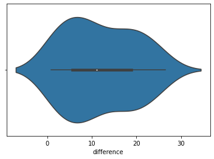

```python
sns.violinplot(x=final["difference"])
```

So I do not see a normal distribution here which is okay because the biggest chunk of our data actually falls between 0 and 10 percent meaning I was a bit more accurate on average. The median was a round 12% and the IQR was from 5% to 20%. Lets see how the data would do in this years season.

```python
final_2020["QBwin"] = (8 * (final["TD"].astype(float)/(final["Int"].astype(float) + final["Fmb"].astype(float))) + \
          1.94 * (final["Cmp%"].astype(float)) - \
          13.162 * final['Sk'].astype(float)/final['G'].astype(float))/2

prediction = abs(final_2020["Win Percentage"] - final_2020["QBwin"])

prediction.mean()
```

```
19.35355429143091
```

# Policy and Insight Decisions

After analyzing the data from the 2019 season and comparing Quarterback statistics to their win rates I have found that the statistics that are most important are their touchdown per turnovers, completion percentage, and sacks per game. With that information being discovered teams should focus on acquiring efficient Quarterbacks. Quarterbacks who throw more touchdowns, have fewer turnovers, do not get sacked often, and complete a higher percentage of their passes simply win more games. There is a false narrative that the quarterbacks who throw for the most yards and touchdowns are the better ones, but just because they have higher stats does not mean that they are efficient. Negatives seem to outweigh the positives, like we saw with Jameis Winston, who threw for the most yards and threw for a lot of touchdowns, and yet his win rate was very bad. This is because he had a poor completion percentage and also had more turnovers than touchdowns. Efficiency reigned supreme for Quarterbacks who won the most games in the 2019 season, and teams should draft and acquire efficient quarterbacks if they want to win more games.

# Conclusion